# Lab6_Presentation

Linda Gai

10/14/2016

## Introduction

I am working on a project on mental health (specifically suicidal ideation) and trolling among Reddit users, along with Lacey. Generally, we are interested in whether we can identify users that are depressed, and their identifying characteristics. Our ultimate goal is to come up with models of behavior for users that admit to having suicidal ideation on Reddit’s r/depression subreddit. That is, we plan to look into the suicidal users’ post history to answer questions about their behavior. Specifically, I am interested in developing a logistic regression model to predict whether a user will make a post containing thoughts of suicidal ideation, based on their post history. To do this, I will first examine the word choice and sentiment differences between suicidal and non-suicidal users.

Reddit is a popular online message board, commonly used to share news and images, as well as discussion on user-created topics. It is the 11th most popular website in the US, ranked just under Twitter which comes in at #10. Notably, some discussion boards (known as “subreddits”) are used to provide and ask for advice and support, and many users share deeply personal information and emotional states. We are particularly interested in how we might be able to identify suicidal ideation among Reddit users, as many users post suicide notes and/or reveal intention to commit suicide.

## Methods

### Collected data set(s)

We collected the following datasets:

- all the comments from r/depression from June 1-30, 2016, in JSON format
- a large training set of approximately 600 comments from mental health subreddits, including but not limited to r/depression. The comments were obtained and scored as follows:
  - ~110 submissions (i.e. comments from the original poster), scored by both Lacey and Linda, randomly sampled from a set of ~20 of the largest mental health subreddits excluding r/depression, using the PRAW python package’s random sampling function. Comments were scored for current suicidal ideation, past suicidal ideation, and the presence/absence of mood or anxiety disorders. ~50% of these posts indicate suicidal ideation.
  - ~500 comments (consisting of both submissions and replies) from r/depression that were posted in June. Lacey and Linda each scored ~300 comments, with ~100 comments scored by both. Comments were scored only for the presence of suicidal ideation, and were obtained from June posts in r/depression. Only about 30 of these comments indicate suicide ideation.
  - a JSON parser (written with help from John) that takes in a JSON file and spits outs a data frame that contains the attributes of a submission, along with all of its replies

### Analysis

#### Classification of Posts into Suicidal and Non-suicidal Categories

We created a classification algorithm that will search individual posts for phrases that match phrases that indicate suicidal ideation. The idea is that, since we are only interested in the behavior of suicidal users, we want an algorithm that has very high sensitivity (i.e. will identify only true positives of suicidal users), but we don’t care too much about the specificity of the algorithm.

#### Exploratory Data Analysis

##### How does word choice differ between suicidal and non-suicidal users?

Here, I compare word tokens between suicidal and non-suicidal POSTS (not comments), using the classified set that has already been scored by the algorithm.

```
## # A tibble: 6 × 4
##         word         sui     not.sui         diff
##        <chr>       <dbl>       <dbl>        <dbl>
## 1       feel 0.016862409 0.022670404 -0.005807995
## 2 depression 0.007011212 0.010956906 -0.003945694
## 3       time 0.011212023 0.013869328 -0.002657306
## 4     people 0.010117445 0.012447301 -0.002329855
## 5    feeling 0.003313315 0.005359951 -0.002046635
## 6        day 0.006715380 0.008226795 -0.001511415
```

```
## # A tibble: 6 × 4
##      word         sui     not.sui        diff
##     <chr>       <dbl>       <dbl>       <dbl>
## 1    dont 0.003549981 0.002055559 0.001494421
## 2 fucking 0.005384138 0.003860441 0.001523697
## 3 anymore 0.005916635 0.004006290 0.001910345
## 4    live 0.005709552 0.003081060 0.002628492
## 5    kill 0.005472887 0.001267063 0.004205824
## 6     die 0.006389965 0.001449374 0.004940591
```

```
## [1] -0.005807995  0.004940591
```

```
##  [1] feel       depression time       people     feeling    day
##  [7] friends    depressed  hard       bad        feel       depression
## [13] time       people     feeling    day        friends    depressed
## [19] hard       bad
## 10 Levels: feel depression time people feeling day friends ... bad
```

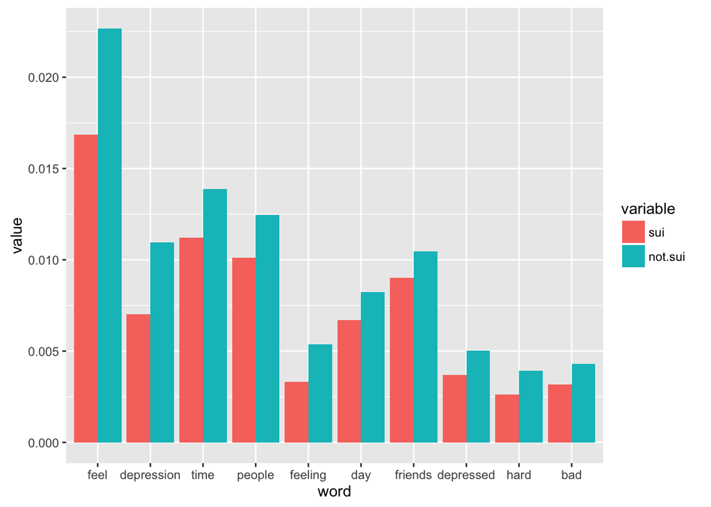

##### What are the overall sentiment pattern differences between suicidal and non-suicidal posts?

```
## data.table + dplyr code now lives in dtplyr.
## Please library(dtplyr)!
```

[figure not shown]

##### What are the other subreddits that suicidal users post in?

```r
load(file="Classified_Posts/June_Authors_Data.RData")

not.dep.sent <- post.sent %>%
  filter(subreddit_id!="t5_2qqqf") %>%
  group_by(sentiment,subreddit_id) %>%
  summarize(n=n()) %>%
  filter(n>100) %>%
  arrange(desc(n))

x <- sort(table(user.post.data$subreddit_id),decreasing=T)[1:10]
names(x)<-c("depression",'AskReddit','datfeel','SuicideWatch',
            'Fireteams','asktransgender','leagueoflegends','DotA2',
            'Anxiety','ForeverAlone')
x
```

```
##      depression       AskReddit         datfeel    SuicideWatch
##            2596             817             339             294
##       Fireteams  asktransgender leagueoflegends           DotA2
##             234             212             207             179
##         Anxiety    ForeverAlone
##             172             170
```